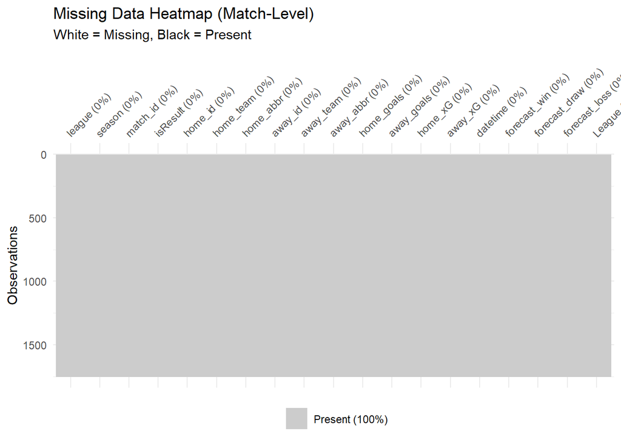

```r
# 3. Missing data pattern visualisation
vis_miss(matches_df, sort_miss = TRUE) +
  labs(
    title = "Missing Data Heatmap (Match-Level)",
    subtitle = "White = Missing, Black = Present"
  )
```

This shows we have no missing data, which is great. I’ll now run the same pipeline for carries, take-on attempts and touches. Since these are all possession-based stats, I can run them in one piece of code.

```r
# Fetch player possession stats for each league
possession_df <- fb_big5_advanced_season_stats(
  season_end_year = 2024,
  stat_type = "possession",
  team_or_player = "player",
  time_pause = 3
)

possession_df <- bind_rows(possession_df)

# Filter for the variables of interest
vars_of_interest <- c("Carries_Carries", "Att_Take", "Touches_Touches")

# ---- Missing Values Analysis ----
missing_summary <- possession_df %>%
  summarise(across(all_of(vars_of_interest), ~sum(is.na(.)))) %>%
  pivot_longer(cols = everything(), names_to = "Column", values_to = "Missing_Count") %>%
  mutate(Missing_Percent = round(Missing_Count / nrow(possession_df) * 100, 2)) %>%
  arrange(desc(Missing_Percent))

print(missing_summary)
```

```
## # A tibble: 3 × 3
##   Column          Missing_Count Missing_Percent
##   <chr>                   <int>           <dbl>
## 1 Carries_Carries             0               0
## 2 Att_Take                    0               0
## 3 Touches_Touches             0               0
```

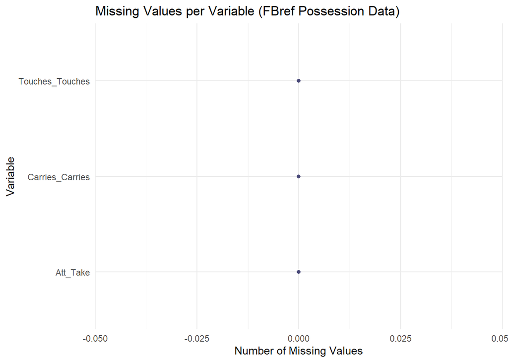

```r
# Visualise missing values per variable
gg_miss_var(possession_df[, vars_of_interest], show_pct = TRUE) +
  labs(
    title = "Missing Values per Variable (FBref Possession Data)",
    x = "Variable",
    y = "Number of Missing Values"
  ) +
  theme_minimal()
```

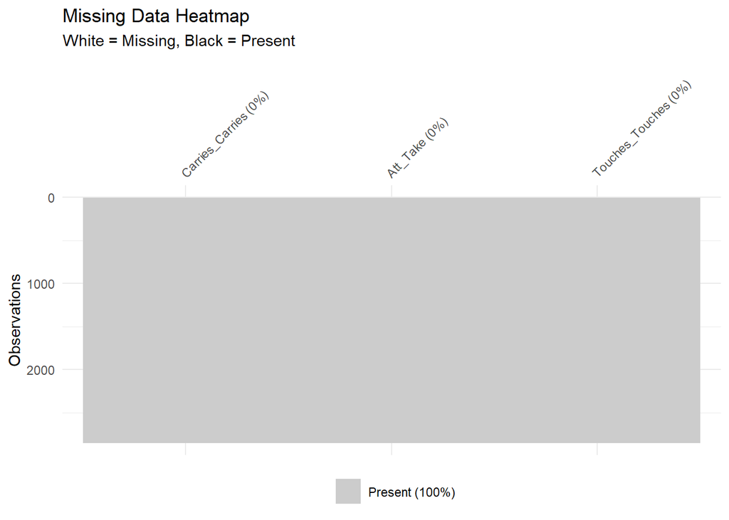

```r
# Heatmap of missingness across players
vis_miss(possession_df[, vars_of_interest], sort_miss = TRUE) +
  labs(
    title = "Missing Data Heatmap",
    subtitle = "White = Missing, Black = Present"
  )
```

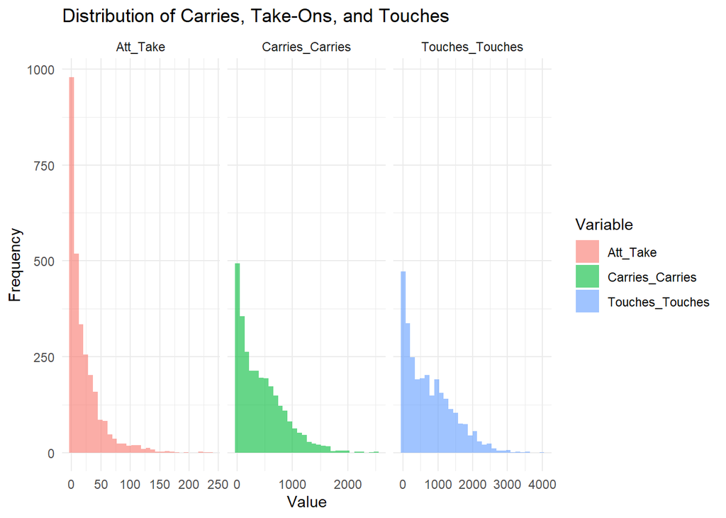

```r
# ---- Distribution Analysis ----
possession_df %>%
  pivot_longer(cols = all_of(vars_of_interest),
               names_to = "Variable", values_to = "Value") %>%
  drop_na(Value) %>%
  ggplot(aes(x = Value, fill = Variable)) +
  geom_histogram(bins = 30, alpha = 0.6, position = "identity") +
  facet_wrap(~Variable, scales = "free_x") +
  labs(
    title = "Distribution of Carries, Take-Ons, and Touches",
    x = "Value",
    y = "Frequency"
  ) +
  theme_minimal()
```

The lack of missing values is an encouraging sign. The distribution of the variables seems reasonable, it’s quite interesting to see the sharp peaks for lower values which could indicate differences in position. Further analysis with facet-wrap for more specific data questions could indicate why these peaks are there (possibly due to differences in player profiles).